# Tutorial R - Introdução a Manipulação de Dados

## Importando os dados e bibliotecas

A biblioteca utilizada neste tutorial é a **tidyverse**.

```r
# Instale o tidyverse executando a linha abaixo
# install.packages("tidyverse")
setwd("~/tutorial_r")
library(tidyverse)
dados <- read_csv(("data/titanic.csv"))
dados$Age <- as.integer(dados$Age)
dados %>% glimpse()
```

```
Observations: 891
Variables: 12
$ PassengerId <int> 1, 2, 3, 4, 5, 6, 7, 8, 9, 10, 11, 12, 13, 14, 15, 16, 17, 18, 19, 20, 21, 22, 23, 24, 25, 26, 27, 28, 29,...
$ Survived    <int> 0, 1, 1, 1, 0, 0, 0, 0, 1, 1, 1, 1, 0, 0, 0, 1, 0, 1, 0, 1, 0, 1, 1, 1, 0, 1, 0, 0, 1, 0, 0, 1, 1, 0, 0, 0...
$ Pclass      <int> 3, 1, 3, 1, 3, 3, 1, 3, 3, 2, 3, 1, 3, 3, 3, 2, 3, 2, 3, 3, 2, 2, 3, 1, 3, 3, 3, 1, 3, 3, 1, 1, 3, 2, 1, 1...
$ Name        <chr> "Braund, Mr. Owen Harris", "Cumings, Mrs. John Bradley (Florence Briggs Thayer)", "Heikkinen, Miss. Laina"...
$ Sex         <chr> "male", "female", "female", "female", "male", "male", "male", "male", "female", "female", "female", "femal...
$ Age         <int> 22, 38, 26, 35, 35, NA, 54, 2, 27, 14, 4, 58, 20, 39, 14, 55, 2, NA, 31, NA, 35, 34, 15, 28, 8, 38, NA, 19...
$ SibSp       <int> 1, 1, 0, 1, 0, 0, 0, 3, 0, 1, 1, 0, 0, 1, 0, 0, 4, 0, 1, 0, 0, 0, 0, 0, 3, 1, 0, 3, 0, 0, 0, 1, 0, 0, 1, 1...
$ Parch       <int> 0, 0, 0, 0, 0, 0, 0, 1, 2, 0, 1, 0, 0, 5, 0, 0, 1, 0, 0, 0, 0, 0, 0, 0, 1, 5, 0, 2, 0, 0, 0, 0, 0, 0, 0, 0...
$ Ticket      <chr> "A/5 21171", "PC 17599", "STON/O2. 3101282", "113803", "373450", "330877", "17463", "349909", "347742", "2...
$ Fare        <dbl> 7.2500, 71.2833, 7.9250, 53.1000, 8.0500, 8.4583, 51.8625, 21.0750, 11.1333, 30.0708, 16.7000, 26.5500, 8....
$ Cabin       <chr> NA, "C85", NA, "C123", NA, NA, "E46", NA, NA, NA, "G6", "C103", NA, NA, NA, NA, NA, NA, NA, NA, NA, "D56",...
$ Embarked    <chr> "S", "C", "S", "S", "S", "Q", "S", "S", "S", "C", "S", "S", "S", "S", "S", "S", "Q", "S", "S", "C", "S", "...
```

Breve descrição das informações disponíveis:

- Survived: Sobrevivente? 0 = Não, 1 = Sim;
- Pclass: Classe do bilhete: 1 = 1ª classe, 2 = 2ª classe, 3 = 3ª classe;
- Sex: Sexo;
- Age: Idade;
- SibSp: # de irmãos ou conjuges a bordo ;
- Parch: # pais e filhos a bordo;
- Ticket: Número do bilhete;
- Fare: taxa paga;
- Cabin: Número da cabine;
- Embarked: Porto de Embarque: C = Cherbourg, Q = Queensotwn, S = Southampton;

## Filtrando dados

Quais sobreviventes eram do sexo feminino?

```r
dados %>% filter(Survived == 1 & Sex == "female")
```

| PassengerId | Survived | Pclass | Name | Sex | Age | SibSp | Parch | Ticket | Fare | Cabin | Embarked |
| --- | --- | --- | --- | --- | --- | --- | --- | --- | --- | --- | --- |
| 2 | 1 | 1 | Cumings, Mrs. John Bradley (Florence Briggs Thayer) | female | 38 | 1 | 0 | PC 17599 | 71.2833 | C85 | C |
| 3 | 1 | 3 | Heikkinen, Miss. Laina | female | 26 | 0 | 0 | STON/O2. 3101282 | 7.9250 | NA | S |
| 4 | 1 | 1 | Futrelle, Mrs. Jacques Heath (Lily May Peel) | female | 35 | 1 | 0 | 113803 | 53.1000 | C123 | S |
| 9 | 1 | 3 | Johnson, Mrs. Oscar W (Elisabeth Vilhelmina Berg) | female | 27 | 0 | 2 | 347742 | 11.1333 | NA | S |
| 10 | 1 | 2 | Nasser, Mrs. Nicholas (Adele Achem) | female | 14 | 1 | 0 | 237736 | 30.0708 | NA | C |
| 11 | 1 | 3 | Sandstrom, Miss. Marguerite Rut | female | 4 | 1 | 1 | PP 9549 | 16.7000 | G6 | S |
| 12 | 1 | 1 | Bonnell, Miss. Elizabeth | female | 58 | 0 | 0 | 113783 | 26.5500 | C103 | S |
| 16 | 1 | 2 | Hewlett, Mrs. (Mary D Kingcome) | female | 55 | 0 | 0 | 248706 | 16.0000 | NA | S |
| 20 | 1 | 3 | Masselmani, Mrs. Fatima | female | NA | 0 | 0 | 2649 | 7.2250 | NA | C |
| 23 | 1 | 3 | McGowan, Miss. Anna "Annie" | female | 15 | 0 | 0 | 330923 | 8.0292 | NA | Q |

[output cut: 223 more lines]

## Ordenando dados

Exibindo os dados dos sobreviventes por ordem crescente de Fare:

```r
dados %>% filter(Survived == 1) %>%
  arrange(Fare)
```

| PassengerId | Survived | Pclass | Name | Sex | Age | SibSp | Parch | Ticket | Fare | Cabin | Embarked |
| --- | --- | --- | --- | --- | --- | --- | --- | --- | --- | --- | --- |
| 272 | 1 | 3 | Tornquist, Mr. William Henry | male | 25 | 0 | 0 | LINE | 0.0000 | NA | S |
| 805 | 1 | 3 | Hedman, Mr. Oskar Arvid | male | 27 | 0 | 0 | 347089 | 6.9750 | NA | S |
| 128 | 1 | 3 | Madsen, Mr. Fridtjof Arne | male | 24 | 0 | 0 | C 17369 | 7.1417 | NA | S |
| 20 | 1 | 3 | Masselmani, Mrs. Fatima | female | NA | 0 | 0 | 2649 | 7.2250 | NA | C |
| 554 | 1 | 3 | Leeni, Mr. Fahim ("Philip Zenni") | male | 22 | 0 | 0 | 2620 | 7.2250 | NA | C |
| 876 | 1 | 3 | Najib, Miss. Adele Kiamie "Jane" | female | 15 | 0 | 0 | 2667 | 7.2250 | NA | C |
| 37 | 1 | 3 | Mamee, Mr. Hanna | male | NA | 0 | 0 | 2677 | 7.2292 | NA | C |
| 368 | 1 | 3 | Moussa, Mrs. (Mantoura Boulos) | female | NA | 0 | 0 | 2626 | 7.2292 | NA | C |
| 763 | 1 | 3 | Barah, Mr. Hanna Assi | male | 20 | 0 | 0 | 2663 | 7.2292 | NA | C |
| 781 | 1 | 3 | Ayoub, Miss. Banoura | female | 13 | 0 | 0 | 2687 | 7.2292 | NA | C |

[output cut: 332 more lines]

## Selecionando colunas

Só quero saber se sobreviveu ou não, a classe, o sexo e a idade

```r
dados %>%
  select(Survived, Pclass, Sex, Age) %>% na.omit()
```

| Survived | Pclass | Sex | Age |
| --- | --- | --- | --- |
| 0 | 3 | male | 22 |
| 1 | 1 | female | 38 |
| 1 | 3 | female | 26 |
| 1 | 1 | female | 35 |
| 0 | 3 | male | 35 |
| 0 | 1 | male | 54 |
| 0 | 3 | male | 2 |
| 1 | 3 | female | 27 |
| 1 | 2 | female | 14 |
| 1 | 3 | female | 4 |

[output cut: 704 more lines]

### Criando e modificando colunas

- Modificar coluna Sex para F ou M;
- Calcular tamanho da família;
- Calcular número de sobreviventes por sexo e classe;
- Calcular número de sobreviventes por Porto de Embarque

```r
dados %>%
  mutate(FamSize = SibSp + Parch) %>%
  arrange(-FamSize)
```

| PassengerId | Survived | Pclass | Name | Sex | Age | SibSp | Parch | Ticket | Fare | Cabin | Embarked | FamSize |
| --- | --- | --- | --- | --- | --- | --- | --- | --- | --- | --- | --- | --- |
| 160 | 0 | 3 | Sage, Master. Thomas Henry | male | NA | 8 | 2 | CA. 2343 | 69.5500 | NA | S | 10 |
| 181 | 0 | 3 | Sage, Miss. Constance Gladys | female | NA | 8 | 2 | CA. 2343 | 69.5500 | NA | S | 10 |
| 202 | 0 | 3 | Sage, Mr. Frederick | male | NA | 8 | 2 | CA. 2343 | 69.5500 | NA | S | 10 |
| 325 | 0 | 3 | Sage, Mr. George John Jr | male | NA | 8 | 2 | CA. 2343 | 69.5500 | NA | S | 10 |
| 793 | 0 | 3 | Sage, Miss. Stella Anna | female | NA | 8 | 2 | CA. 2343 | 69.5500 | NA | S | 10 |
| 847 | 0 | 3 | Sage, Mr. Douglas Bullen | male | NA | 8 | 2 | CA. 2343 | 69.5500 | NA | S | 10 |
| 864 | 0 | 3 | Sage, Miss. Dorothy Edith "Dolly" | female | NA | 8 | 2 | CA. 2343 | 69.5500 | NA | S | 10 |
| 60 | 0 | 3 | Goodwin, Master. William Frederick | male | 11 | 5 | 2 | CA 2144 | 46.9000 | NA | S | 7 |
| 72 | 0 | 3 | Goodwin, Miss. Lillian Amy | female | 16 | 5 | 2 | CA 2144 | 46.9000 | NA | S | 7 |
| 387 | 0 | 3 | Goodwin, Master. Sidney Leonard | male | 1 | 5 | 2 | CA 2144 | 46.9000 | NA | S | 7 |

[output cut: 881 more lines]

```r
dados %>%
  mutate(Sex = ifelse(Sex == "female", "F", "M"))
```

| PassengerId | Survived | Pclass | Name | Sex | Age | SibSp | Parch | Ticket | Fare | Cabin | Embarked |
| --- | --- | --- | --- | --- | --- | --- | --- | --- | --- | --- | --- |
| 1 | 0 | 3 | Braund, Mr. Owen Harris | M | 22 | 1 | 0 | A/5 21171 | 7.2500 | NA | S |
| 2 | 1 | 1 | Cumings, Mrs. John Bradley (Florence Briggs Thayer) | F | 38 | 1 | 0 | PC 17599 | 71.2833 | C85 | C |
| 3 | 1 | 3 | Heikkinen, Miss. Laina | F | 26 | 0 | 0 | STON/O2. 3101282 | 7.9250 | NA | S |
| 4 | 1 | 1 | Futrelle, Mrs. Jacques Heath (Lily May Peel) | F | 35 | 1 | 0 | 113803 | 53.1000 | C123 | S |
| 5 | 0 | 3 | Allen, Mr. William Henry | M | 35 | 0 | 0 | 373450 | 8.0500 | NA | S |
| 6 | 0 | 3 | Moran, Mr. James | M | NA | 0 | 0 | 330877 | 8.4583 | NA | Q |
| 7 | 0 | 1 | McCarthy, Mr. Timothy J | M | 54 | 0 | 0 | 17463 | 51.8625 | E46 | S |
| 8 | 0 | 3 | Palsson, Master. Gosta Leonard | M | 2 | 3 | 1 | 349909 | 21.0750 | NA | S |
| 9 | 1 | 3 | Johnson, Mrs. Oscar W (Elisabeth Vilhelmina Berg) | F | 27 | 0 | 2 | 347742 | 11.1333 | NA | S |
| 10 | 1 | 2 | Nasser, Mrs. Nicholas (Adele Achem) | F | 14 | 1 | 0 | 237736 | 30.0708 | NA | C |

[output cut: 881 more lines]

```r
dados %>%
  filter(Survived == 1) %>%
  group_by(Pclass, Sex) %>%
  summarise(n_survived = n()) %>%
  arrange(-n_survived) %>% na.omit()
```

| Pclass | Sex | n_survived |
| --- | --- | --- |
| 1 | female | 91 |
| 3 | female | 72 |
| 2 | female | 70 |
| 3 | male | 47 |
| 1 | male | 45 |
| 2 | male | 17 |

```r
dados %>%
  filter(Survived == 1) %>%
  group_by(Embarked) %>%
  summarise(num_survived = n()) %>%
  arrange(-num_survived) %>% na.omit()
```

| Embarked | num_survived |
| --- | --- |
| S | 217 |
| C | 93 |
| Q | 30 |

### Combinando linhas

Sobreviventes com maior e menor Fare (taxa de pagamento);

```r
top_10 <- dados %>%
  filter(Survived == 1) %>%
  arrange(-Fare) %>% head(10)
top_minus_10 <- dados %>%
  filter(Survived == 1) %>%
  arrange(Fare) %>% head(10)
rbind(top_10, top_minus_10) %>%
  arrange(Fare)
```

| PassengerId | Survived | Pclass | Name | Sex | Age | SibSp | Parch | Ticket | Fare | Cabin | Embarked |
| --- | --- | --- | --- | --- | --- | --- | --- | --- | --- | --- | --- |
| 272 | 1 | 3 | Tornquist, Mr. William Henry | male | 25 | 0 | 0 | LINE | 0.0000 | NA | S |
| 805 | 1 | 3 | Hedman, Mr. Oskar Arvid | male | 27 | 0 | 0 | 347089 | 6.9750 | NA | S |
| 128 | 1 | 3 | Madsen, Mr. Fridtjof Arne | male | 24 | 0 | 0 | C 17369 | 7.1417 | NA | S |
| 20 | 1 | 3 | Masselmani, Mrs. Fatima | female | NA | 0 | 0 | 2649 | 7.2250 | NA | C |
| 554 | 1 | 3 | Leeni, Mr. Fahim ("Philip Zenni") | male | 22 | 0 | 0 | 2620 | 7.2250 | NA | C |
| 876 | 1 | 3 | Najib, Miss. Adele Kiamie "Jane" | female | 15 | 0 | 0 | 2667 | 7.2250 | NA | C |
| 37 | 1 | 3 | Mamee, Mr. Hanna | male | NA | 0 | 0 | 2677 | 7.2292 | NA | C |
| 368 | 1 | 3 | Moussa, Mrs. (Mantoura Boulos) | female | NA | 0 | 0 | 2626 | 7.2292 | NA | C |
| 763 | 1 | 3 | Barah, Mr. Hanna Assi | male | 20 | 0 | 0 | 2663 | 7.2292 | NA | C |
| 781 | 1 | 3 | Ayoub, Miss. Banoura | female | 13 | 0 | 0 | 2687 | 7.2292 | NA | C |

[output cut: 10 more lines]

Exibir o número de homens que sobreviveram ou não, de acordo com a maioridade (>= 18 anos)

[output not shown]

## Criando algumas visualizações

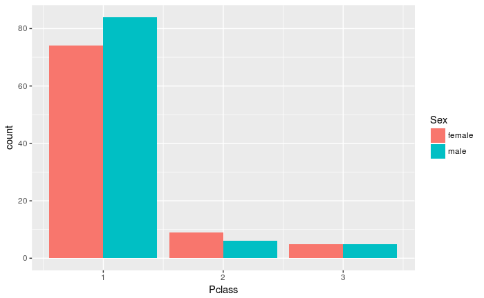

```r
dados %>% na.omit() %>%
  group_by(Sex, Pclass) %>%
  ggplot(aes(x = Pclass, fill=Sex)) +
  geom_bar(position = "dodge")
```

```r
dados %>% na.omit() %>%
  mutate(Survived = ifelse(Survived == 1, "Yes", "No")) %>%
  ggplot(aes(x = Age, y = Fare, color = Sex)) +
  geom_point(alpha = .6) +
  facet_grid(~Survived)
```

[output not shown]

Existe alguma relação entre o Porto de Embarque do passageiro e sua sobrevivência?

```r
model <- lm(Survived ~ ., dados %>% select(-PassengerId, -Name, -Ticket))
summary(model)
```

```
Call:
lm(formula = Survived ~ ., data = dados %>% select(-PassengerId,
    -Name, -Ticket))

Residuals:
    Min      1Q  Median      3Q     Max
-0.5689  0.0000  0.0000  0.0000  0.8521

Coefficients: (2 not defined because of singularities)
                      Estimate Std. Error t value Pr(>|t|)
(Intercept)           1.242897   0.658423   1.888  0.06567 .
Pclass               -0.445362   0.359868  -1.238  0.22244
Sexmale              -0.445847   0.098664  -4.519 4.64e-05 ***
Age                  -0.012421   0.004572  -2.717  0.00938 **
SibSp                 0.173770   0.242209   0.717  0.47690
Parch                 0.226075   0.246355   0.918  0.36379
Fare                  0.002379   0.001348   1.765  0.08446 .
CabinA16              0.530686   0.553609   0.959  0.34300
CabinA20              0.947721   0.537908   1.762  0.08504 .
CabinA23              1.196015   0.653006   1.832  0.07379 .
CabinA24             -0.461388   0.645517  -0.715  0.47853
CabinA26              1.259427   0.488696   2.577  0.01339 *
CabinA31              1.071396   0.480550   2.230  0.03093 *
CabinA34             -0.323532   0.856759  -0.378  0.70753
CabinA36             -0.241870   0.617506  -0.392  0.69718
CabinA5               0.447757   0.506015   0.885  0.38104
CabinA6               0.537029   0.638672   0.841  0.40498
CabinA7               0.270858   0.488791   0.554  0.58229
CabinB101            -0.135972   0.797145  -0.171  0.86534
CabinB18              0.211069   0.495691   0.426  0.67232
CabinB19             -0.048314   0.638408  -0.076  0.94002
CabinB20              0.039495   0.648322   0.061  0.95170
CabinB22             -0.385832   0.752968  -0.512  0.61092
CabinB3              -0.366959   0.770909  -0.476  0.63642
CabinB30              0.082138   0.536093   0.153  0.87893
CabinB35              0.335681   0.429889   0.781  0.43907
CabinB37              0.298070   0.490608   0.608  0.54661
CabinB38             -0.230516   0.629909  -0.366  0.71616
CabinB39             -0.094200   0.709548  -0.133  0.89499
CabinB4               0.683036   0.493011   1.385  0.17290
```

[output cut: 103 more lines]

```
CabinF33              0.606467   0.390435   1.553  0.12751
CabinF4              -0.139215   0.637687  -0.218  0.82820
CabinF G63            0.667915   0.598519   1.116  0.27050
CabinF G73            0.419492   0.522710   0.803  0.42656
CabinG6                     NA         NA      NA       NA
CabinT               -0.251811   0.634624  -0.397  0.69344
EmbarkedQ                   NA         NA      NA       NA
EmbarkedS             0.374606   0.420357   0.891  0.37769
---
Signif. codes:  0 ‘***’ 0.001 ‘**’ 0.01 ‘*’ 0.05 ‘.’ 0.1 ‘ ’ 1

Residual standard error: 0.3395 on 44 degrees of freedom
  (708 observations deleted due to missingness)
Multiple R-squared:  0.8743,    Adjusted R-squared:   0.48
F-statistic: 2.217 on 138 and 44 DF,  p-value: 0.001497
```